# CS498 AML HW6

Pengyu Cheng

10/19/2018

### Question a): Regress house price (variable 14) against all others, and use leverage, Cook’s distance, and standardized residuals to find possible outliers. Produce a diagnostic plot that allows you to identify possible outliers

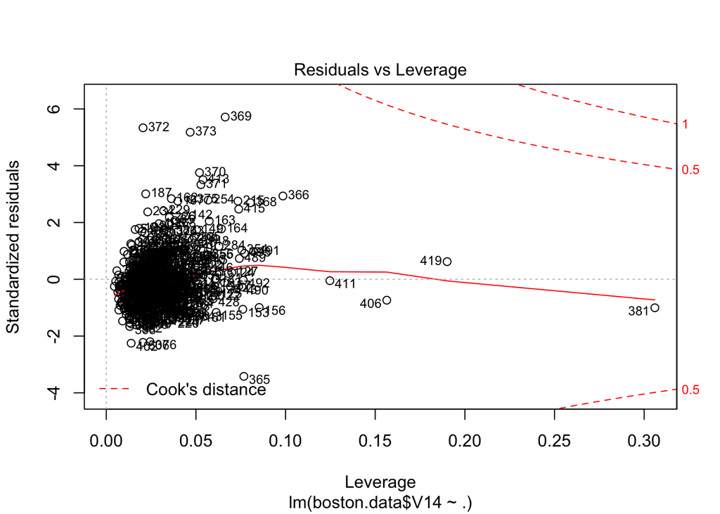

```r
library(data.table)
boston.data = fread('https://archive.ics.uci.edu/ml/machine-learning-databases/housing/housing.data')
num.points = nrow(boston.data)
model = lm(boston.data$V14~., data = boston.data)
#plot all points id for identification
plot(model, which = 5, id.n=num.points)
```

### Question b): Remove all the points you suspect as outliers, and compute a new regression. Produce a diagnostic plot that allows you to identify possible outliers.

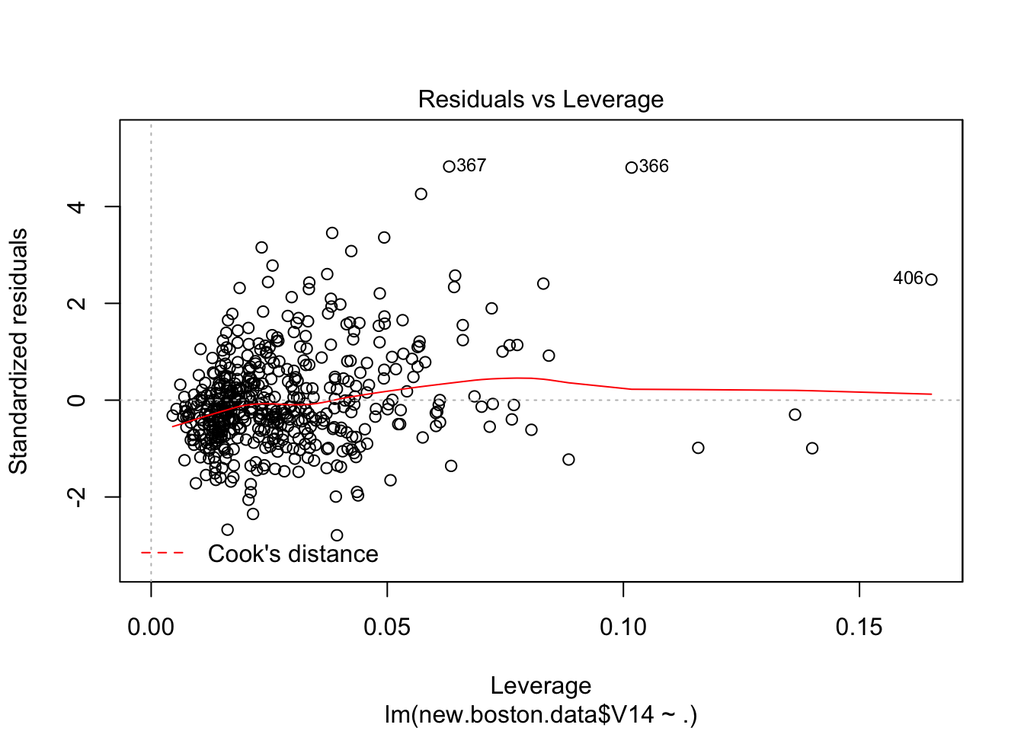

```r
new.boston.data = boston.data[-c(369, 372, 373, 370, 366, 365, 381, 419, 406, 411),]
new.model = lm(new.boston.data$V14~., data=new.boston.data)
plot(new.model, which = 5)
```

### Question c): Apply a Box-Cox transformation to the dependent variable – what is the best value of the parameter?

```r
library(MASS)
boxcox.transform = boxcox(new.model)
```

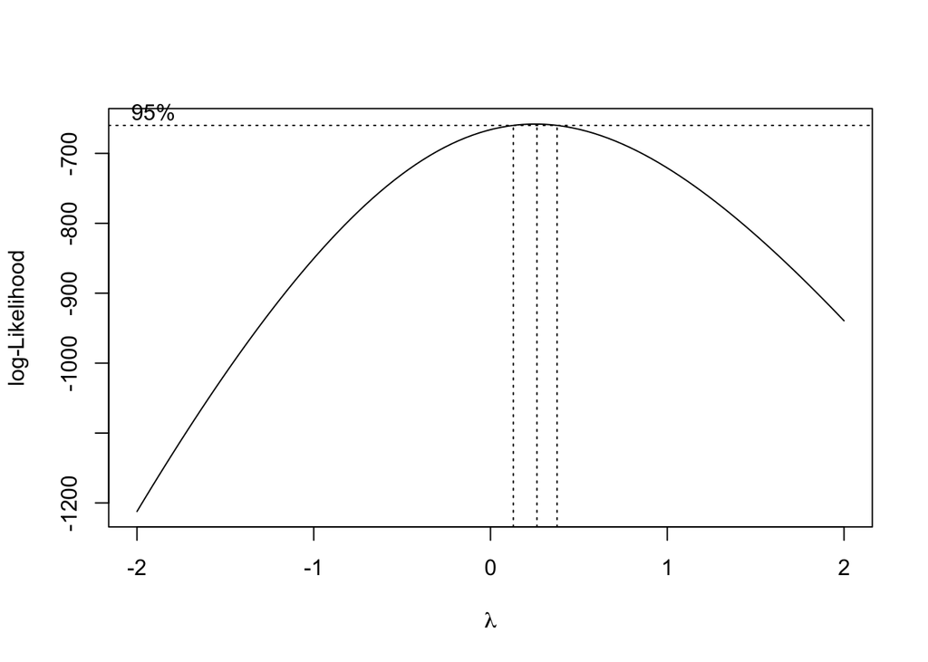

```r
best.lambda = boxcox.transform$x[which(boxcox.transform$y == max(boxcox.transform$y))]
```

The best parameter of $\lambda$ is 0.2626263

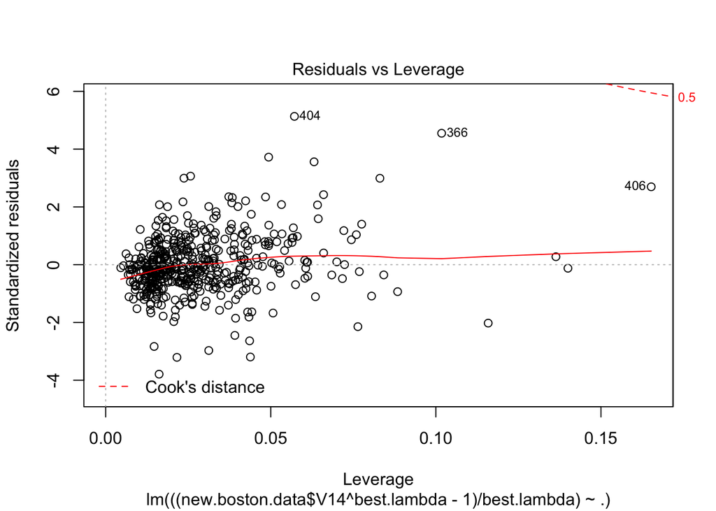

```r
transform.model = lm(((new.boston.data$V14^best.lambda - 1)/best.lambda) ~., data=new.boston.data)
plot(transform.model, which = 5)
```

[figure not shown]

```r
plot(new.boston.data$V14, (fitted.values(transform.model) * best.lambda + 1)^(1/best.lambda), xlab = "fitted value", ylab = "ture value")
abline(1,1,col='red')
```

### Plot of Standardized residuals vs Fitted values for the final linear regression model obtained before removing all outliers and transforming the dependent variable

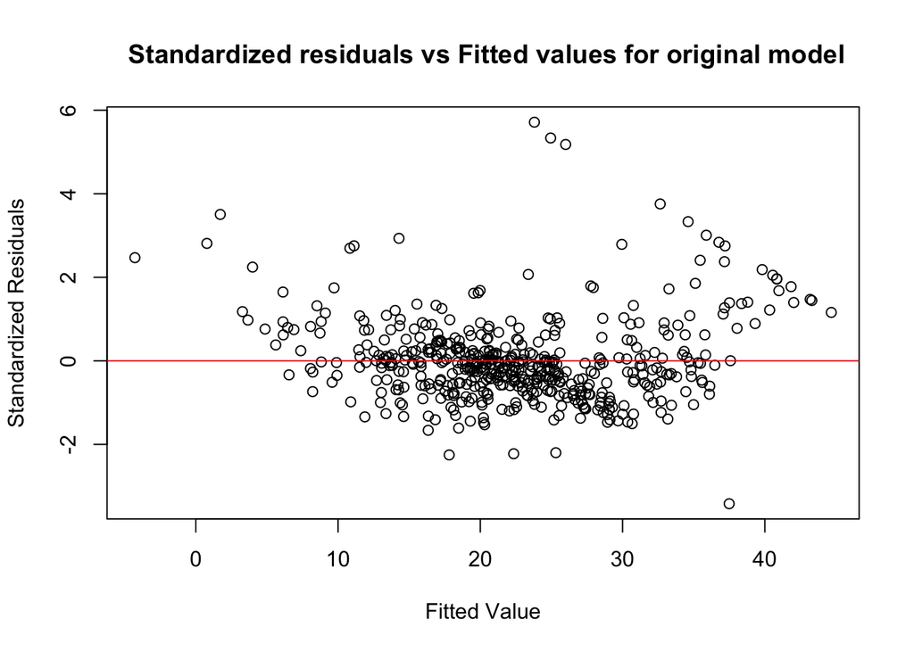

```r
std.res = rstandard(model)
plot(model$fitted.values, std.res, ylab="Standardized Residuals", xlab="Fitted Value", main=" Standardized residuals vs Fitted values for original model")
abline(0, 0, col='red')
```

### Plot of Standardized residuals vs Fitted values for the final linear regression model obtained after removing all outliers and transforming the dependent variable

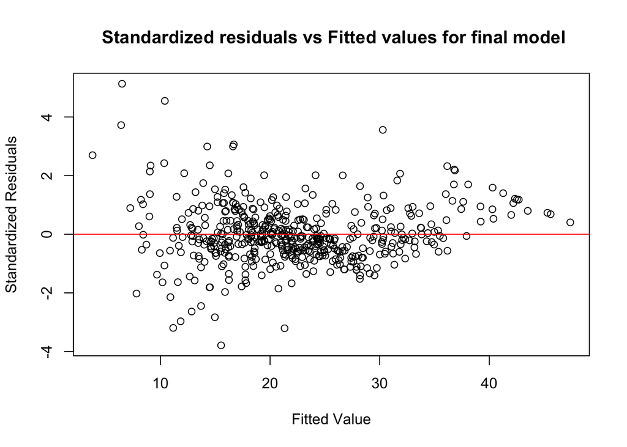

```r
transform.std.res = rstandard(transform.model)
#scale back to original range
transform.fitted.values = (fitted.values(transform.model) * best.lambda + 1)^(1/best.lambda)
plot(transform.fitted.values, transform.std.res, ylab="Standardized Residuals", xlab="Fitted Value", main=" Standardized residuals vs Fitted values for final model")
abline(0, 0, col='red')
```